# Random Walks & Mixing

**formalML** — Graph Theory Track (Topic 2 of 4)  
**Prerequisites:** Graph Laplacians & Spectrum  
**Difficulty:** Intermediate  
**Author:** Jonathan Rocha

This notebook develops the theory of random walks on graphs — Markov chains whose transition structure is encoded in the adjacency matrix. We construct the transition matrix $P = D^{-1}A$, prove convergence to the stationary distribution $\boldsymbol{\pi}$, bound the mixing time through the spectral gap, and connect hitting times to effective resistance in electrical networks. These ideas power modern graph algorithms from PageRank to DeepWalk.

## Overview & Motivation

In the Graph Laplacians & Spectrum topic, we studied graphs through the lens of the Laplacian matrix $L = D - A$ and its eigenvalues. The normalized Laplacian $\mathcal{L} = I - D^{-1/2}AD^{-1/2}$ made a brief appearance alongside the **transition matrix** $P = D^{-1}A$. Now we place $P$ center stage.

A **random walk** on a graph is the simplest possible stochastic process on a network: at each step, the walker moves to a uniformly random neighbor. Despite this simplicity, the walk's behavior reveals deep structural properties:

- **How quickly does the walk forget its starting position?** The *mixing time* measures convergence to the stationary distribution. Fast mixing implies good connectivity — the graph has no bottlenecks.
- **How far apart are two vertices in "random walk distance"?** The *hitting time* $h(i,j)$ measures the expected number of steps to reach $j$ from $i$. Unlike shortest-path distance, hitting time is sensitive to the graph's branching structure and reflects the "difficulty" of finding a target by random exploration.
- **What is the electrical interpretation?** Identifying edges with unit resistors turns the graph into an electrical network. The *effective resistance* between two vertices equals the commute time (normalized by total edge weight) — a beautiful equivalence between probability and physics.

The spectral gap $\gamma = 1 - \lambda_2(P) = \lambda_2(\mathcal{L})$ is the key quantity: it controls mixing time ($t_{\mathrm{mix}} = \Theta(1/\gamma)$), bounds hitting times, and characterizes **expander graphs** — sparse graphs that mix as fast as dense ones.

## Setup

```python
# Core dependencies
import numpy as np
import matplotlib.pyplot as plt
import matplotlib.gridspec as gridspec
import matplotlib.patches as mpatches
from matplotlib.colors import LinearSegmentedColormap, Normalize
from matplotlib.lines import Line2D
import networkx as nx
from scipy.linalg import eigh, pinv
from scipy.sparse.linalg import eigs
import warnings
warnings.filterwarnings('ignore')

# formalML palette
TEAL = '#0F6E56'
PURPLE = '#534AB7'
AMBER = '#D97706'
SLATE = '#6B6B6B'
LIGHT_BG = '#FAFAF8'

# Seeded RNG for reproducibility
rng = np.random.default_rng(42)

# Utility: build named graphs
def path_graph(n):
    A = np.zeros((n, n))
    for i in range(n - 1):
        A[i, i+1] = A[i+1, i] = 1
    return A

def cycle_graph(n):
    A = path_graph(n)
    A[0, n-1] = A[n-1, 0] = 1
    return A

def complete_graph(n):
    A = np.ones((n, n)) - np.eye(n)
    return A

def star_graph(n):
    A = np.zeros((n, n))
    for i in range(1, n):
        A[0, i] = A[i, 0] = 1
    return A

def barbell_graph(k):
    n = 2 * k
    A = np.zeros((n, n))
    for i in range(k):
        for j in range(i+1, k):
            A[i, j] = A[j, i] = 1
    for i in range(k, n):
        for j in range(i+1, n):
            A[i, j] = A[j, i] = 1
    A[k-1, k] = A[k, k-1] = 1
    return A

def grid_graph(m):
    n = m * m
    A = np.zeros((n, n))
    for i in range(m):
        for j in range(m):
            v = i * m + j
            if j + 1 < m:
                A[v, v+1] = A[v+1, v] = 1
            if i + 1 < m:
                A[v, v+m] = A[v+m, v] = 1
    return A

def hypercube_graph(d):
    n = 2**d
    A = np.zeros((n, n))
    for i in range(n):
        for bit in range(d):
            j = i ^ (1 << bit)
            A[i, j] = 1
    return A

def transition_matrix(A):
    d = A.sum(axis=1)
    D_inv = np.diag(1.0 / np.maximum(d, 1e-12))
    return D_inv @ A

def stationary_dist(A):
    d = A.sum(axis=1)
    return d / d.sum()

def laplacian_matrix(A):
    return np.diag(A.sum(axis=1)) - A

def normalized_laplacian(A):
    d = A.sum(axis=1)
    d_inv_sqrt = np.diag(1.0 / np.sqrt(np.maximum(d, 1e-12)))
    L = laplacian_matrix(A)
    return d_inv_sqrt @ L @ d_inv_sqrt

def total_variation(p, q):
    return 0.5 * np.sum(np.abs(p - q))

def all_pairs_hitting_times(A):
    n = len(A)
    P = transition_matrix(A)
    H = np.zeros((n, n))
    for j in range(n):
        idx = [i for i in range(n) if i != j]
        P_bar = P[np.ix_(idx, idx)]
        rhs = np.ones(n - 1)
        h_j = np.linalg.solve(np.eye(n - 1) - P_bar, rhs)
        for k, i in enumerate(idx):
            H[i, j] = h_j[k]
    return H

def effective_resistance_matrix(A):
    L = laplacian_matrix(A)
    L_pinv = pinv(L)
    n = len(A)
    R = np.zeros((n, n))
    for i in range(n):
        for j in range(i+1, n):
            e = np.zeros(n)
            e[i] = 1
            e[j] = -1
            R[i, j] = R[j, i] = e @ L_pinv @ e
    return R

print("Setup complete. Named graph constructors and matrix utilities loaded.")
print(f"NumPy {np.__version__}, NetworkX {nx.__version__}")
```

```
Setup complete. Named graph constructors and matrix utilities loaded.
NumPy 2.4.3, NetworkX 3.6.1
```

## 1. Markov Chains on Graphs

### 1.1 The Transition Matrix

A **random walk** on a graph $G = (V, E)$ with $|V| = n$ is a sequence of random variables $X_0, X_1, X_2, \ldots$ taking values in $V$, where at each step the walker moves to a uniformly random neighbor:

$$\Pr[X_{t+1} = j \mid X_t = i] = P_{ij} = \frac{A_{ij}}{d_i}$$

**Definition 1 (Transition Matrix).** The transition matrix of the simple random walk on $G$ is:

$$P = D^{-1}A$$

where $D = \mathrm{diag}(d_1, \ldots, d_n)$ is the degree matrix. Each row of $P$ sums to 1 — $P$ is a **(row) stochastic matrix**.

The entry $P_{ij}$ gives the probability of stepping from vertex $i$ to vertex $j$ in one step. The matrix $P^t$ gives $t$-step transition probabilities: $(P^t)_{ij} = \Pr[X_t = j \mid X_0 = i]$.

### 1.2 Irreducibility and Aperiodicity

- **Irreducible:** Every vertex can be reached from every other vertex (equivalently, $G$ is connected).
- **Aperiodic:** The walk does not get trapped in a deterministic cycle. A connected graph has period 2 iff it is **bipartite**.

**Definition 2 (Ergodic Chain).** A Markov chain is *ergodic* if it is both irreducible and aperiodic. For graph random walks, this means $G$ is connected and non-bipartite.

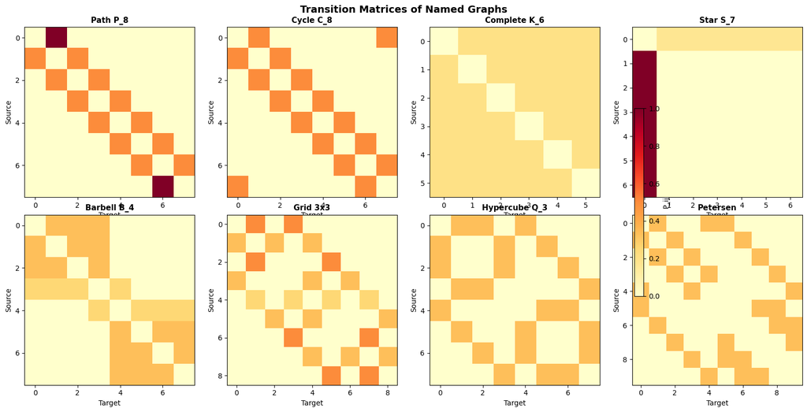

```
Each row of P sums to 1 (stochastic matrix).
```

```python
# === Transition Matrices of Named Graphs ===

fig, axes = plt.subplots(2, 4, figsize=(16, 8))
fig.suptitle('Transition Matrices of Named Graphs', fontsize=14, fontweight='bold', y=0.98)

graphs = {
    'Path P_8': path_graph(8),
    'Cycle C_8': cycle_graph(8),
    'Complete K_6': complete_graph(6),
    'Star S_7': star_graph(7),
    'Barbell B_4': barbell_graph(4),
    'Grid 3x3': grid_graph(3),
    'Hypercube Q_3': hypercube_graph(3),
    'Petersen': nx.to_numpy_array(nx.petersen_graph()),
}

for idx, (name, A) in enumerate(graphs.items()):
    row, col = divmod(idx, 4)
    ax = axes[row, col]
    P = transition_matrix(A)
    n = len(A)
    im = ax.imshow(P, cmap='YlOrRd', vmin=0, vmax=1, aspect='equal')
    ax.set_title(name, fontsize=11, fontweight='bold')
    ax.set_xlabel('Target')
    ax.set_ylabel('Source')
    ax.set_xticks(range(0, n, max(1, n//4)))
    ax.set_yticks(range(0, n, max(1, n//4)))

fig.colorbar(im, ax=axes, shrink=0.6, label='P_ij')
plt.tight_layout()
plt.savefig('walk-trajectories.png', dpi=150, bbox_inches='tight', facecolor='white')
plt.show()
print("Each row of P sums to 1 (stochastic matrix).")
```

## 2. Stationary Distribution & Convergence

### 2.1 The Stationary Distribution

**Definition 3 (Stationary Distribution).** A probability distribution $\boldsymbol{\pi} \in \mathbb{R}^n$ is *stationary* for $P$ if $\boldsymbol{\pi}^T P = \boldsymbol{\pi}^T$.

**Theorem 1 (Stationary Distribution of the Simple Random Walk).** The stationary distribution is $\pi_i = d_i / (2m)$ where $m = |E|$.

*Proof.* We verify $\boldsymbol{\pi}^T P = \boldsymbol{\pi}^T$:

$$(\boldsymbol{\pi}^T P)_j = \sum_{i=1}^n \frac{d_i}{2m} \cdot \frac{A_{ij}}{d_i} = \frac{1}{2m}\sum_{i=1}^n A_{ij} = \frac{d_j}{2m} = \pi_j \quad \square$$

### 2.2 Detailed Balance (Reversibility)

**Theorem 2 (Detailed Balance).** $\pi_i P_{ij} = \pi_j P_{ji}$ for all $i, j$.

*Proof.* $\pi_i P_{ij} = \frac{d_i}{2m} \cdot \frac{A_{ij}}{d_i} = \frac{A_{ij}}{2m} = \frac{A_{ji}}{2m} = \pi_j P_{ji}$ since $A_{ij} = A_{ji}$. $\square$

### 2.3 Convergence

**Theorem 3 (Convergence Theorem).** If the random walk is ergodic (connected, non-bipartite), then for any starting vertex $x$: $\lim_{t \to \infty} P^t(x, \cdot) = \boldsymbol{\pi}$.

*Proof sketch.* By Perron-Frobenius, $\mu_1 = 1$ is simple and $|\mu_i| < 1$ for $i \geq 2$. The spectral decomposition $P^t = \boldsymbol{1}\boldsymbol{\pi}^T + \sum_{i \geq 2} \mu_i^t \mathbf{v}_i \mathbf{w}_i^T$ gives $P^t \to \boldsymbol{1}\boldsymbol{\pi}^T$ as $|\mu_i|^t \to 0$. $\square$

**Corollary 1 (Regular Graphs).** On a $d$-regular graph, $\boldsymbol{\pi} = (1/n, \ldots, 1/n)$ — the uniform distribution.

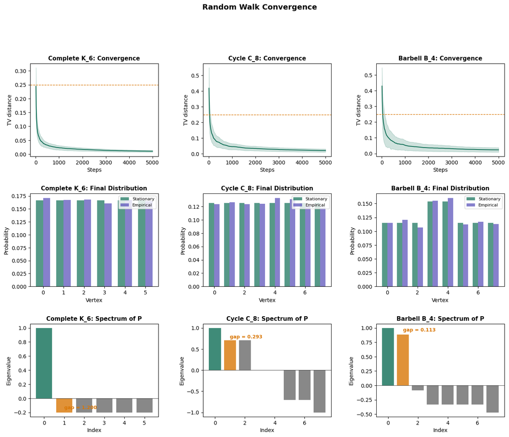

```python
# === Convergence: Empirical Distribution to Stationary Distribution ===

fig = plt.figure(figsize=(16, 12))
gs = gridspec.GridSpec(3, 3, hspace=0.4, wspace=0.35)

test_graphs = {
    'Complete K_6': complete_graph(6),
    'Cycle C_8': cycle_graph(8),
    'Barbell B_4': barbell_graph(4),
}

num_steps = 5000
num_walks = 200

for g_idx, (name, A) in enumerate(test_graphs.items()):
    n = len(A)
    P = transition_matrix(A)
    pi = stationary_dist(A)

    # Simulate multiple walks and track TV distance
    tv_traces = []
    for walk_id in range(num_walks):
        rng_walk = np.random.default_rng(walk_id)
        x = 0
        visits = np.zeros(n)
        tv_history = []
        for t in range(1, num_steps + 1):
            probs = P[x]
            x = rng_walk.choice(n, p=probs)
            visits[x] += 1
            if t % 10 == 0:
                empirical = visits / t
                tv_history.append(total_variation(empirical, pi))
        tv_traces.append(tv_history)

    tv_mean = np.mean(tv_traces, axis=0)
    tv_std = np.std(tv_traces, axis=0)
    t_axis = np.arange(10, num_steps + 1, 10)

    # TV distance over time
    ax1 = fig.add_subplot(gs[0, g_idx])
    ax1.fill_between(t_axis, tv_mean - tv_std, tv_mean + tv_std, alpha=0.2, color=TEAL)
    ax1.plot(t_axis, tv_mean, color=TEAL, linewidth=1.5)
    ax1.axhline(y=0.25, color=AMBER, linestyle='--', linewidth=1)
    ax1.set_xlabel('Steps')
    ax1.set_ylabel('TV distance')
    ax1.set_title(f'{name}: Convergence', fontsize=11, fontweight='bold')

    # Empirical vs stationary (final)
    ax2 = fig.add_subplot(gs[1, g_idx])
    x_pos = np.arange(n)
    width = 0.35
    rng_final = np.random.default_rng(999)
    x = 0
    visits_final = np.zeros(n)
    for t in range(num_steps):
        x = rng_final.choice(n, p=P[x])
        visits_final[x] += 1
    empirical_final = visits_final / num_steps
    ax2.bar(x_pos - width/2, pi, width, label='Stationary', color=TEAL, alpha=0.7)
    ax2.bar(x_pos + width/2, empirical_final, width, label='Empirical', color=PURPLE, alpha=0.7)
    ax2.set_xlabel('Vertex')
    ax2.set_ylabel('Probability')
    ax2.set_title(f'{name}: Final Distribution', fontsize=11, fontweight='bold')
    ax2.legend(fontsize=8)

    # Eigenvalues of P
    ax3 = fig.add_subplot(gs[2, g_idx])
    evals_P = np.sort(np.real(np.linalg.eigvals(P)))[::-1]
    colors = [TEAL if i == 0 else (AMBER if i == 1 else SLATE) for i in range(n)]
    ax3.bar(range(n), evals_P, color=colors, alpha=0.8)
    ax3.axhline(y=0, color='black', linewidth=0.5)
    ax3.set_xlabel('Index')
    ax3.set_ylabel('Eigenvalue')
    ax3.set_title(f'{name}: Spectrum of P', fontsize=11, fontweight='bold')
    gap = 1 - evals_P[1] if n > 1 else 1
    ax3.text(1, evals_P[1] + 0.05, f'gap = {gap:.3f}', fontsize=9, color=AMBER, fontweight='bold')

plt.suptitle('Random Walk Convergence', fontsize=14, fontweight='bold', y=1.01)
plt.savefig('distribution-convergence.png', dpi=150, bbox_inches='tight', facecolor='white')
plt.show()
```

## 3. Total Variation & Mixing Time

**Definition 4 (Total Variation Distance).** $\|p - q\|_{\mathrm{TV}} = \frac{1}{2}\sum_{v \in V} |p(v) - q(v)|$

**Definition 5 (Mixing Time).** $t_{\mathrm{mix}}(\varepsilon) = \max_{x \in V} \min\{t \geq 0 : \|P^t(x, \cdot) - \boldsymbol{\pi}\|_{\mathrm{TV}} \leq \varepsilon\}$

By convention, $t_{\mathrm{mix}} = t_{\mathrm{mix}}(1/4)$.

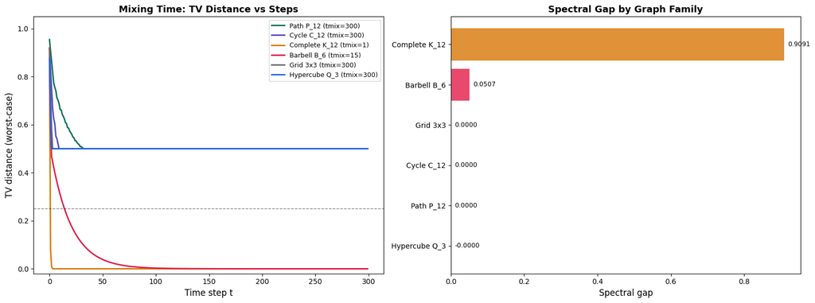

```
Mixing times and spectral gaps:
  Path P_12: t_mix = 300, gap = 0.0000
  Cycle C_12: t_mix = 300, gap = 0.0000
  Complete K_12: t_mix = 1, gap = 0.9091
  Barbell B_6: t_mix = 15, gap = 0.0507
  Grid 3x3: t_mix = 300, gap = 0.0000
  Hypercube Q_3: t_mix = 300, gap = -0.0000
```

```python
# === Mixing Time Comparison ===

fig, axes = plt.subplots(1, 2, figsize=(16, 6))
max_t = 300

families = {
    'Path P_12': path_graph(12),
    'Cycle C_12': cycle_graph(12),
    'Complete K_12': complete_graph(12),
    'Barbell B_6': barbell_graph(6),
    'Grid 3x3': grid_graph(3),
    'Hypercube Q_3': hypercube_graph(3),
}

colors_list = [TEAL, PURPLE, AMBER, '#E11D48', SLATE, '#2563EB']
mix_times = {}
spectral_gaps = {}

ax1 = axes[0]
for idx, (name, A) in enumerate(families.items()):
    n = len(A)
    P = transition_matrix(A)
    pi = stationary_dist(A)
    evals = np.sort(np.real(np.linalg.eigvals(P)))[::-1]
    gap = 1 - max(abs(evals[1]), abs(evals[-1])) if len(evals) > 1 else 1
    spectral_gaps[name] = gap

    worst_tv = np.zeros(max_t)
    for t in range(max_t):
        Pt = np.linalg.matrix_power(P, t)
        tvs = [total_variation(Pt[x], pi) for x in range(n)]
        worst_tv[t] = max(tvs)

    below = np.where(worst_tv <= 0.25)[0]
    t_mix = below[0] if len(below) > 0 else max_t
    mix_times[name] = t_mix
    ax1.plot(range(max_t), worst_tv, color=colors_list[idx], linewidth=2, label=f'{name} (tmix={t_mix})')

ax1.axhline(y=0.25, color='black', linestyle='--', linewidth=1, alpha=0.5)
ax1.set_xlabel('Time step t', fontsize=12)
ax1.set_ylabel('TV distance (worst-case)', fontsize=12)
ax1.set_title('Mixing Time: TV Distance vs Steps', fontsize=13, fontweight='bold')
ax1.legend(fontsize=9)
ax1.set_ylim(-0.02, 1.05)

# Spectral gap bar chart
ax2 = axes[1]
names_sorted = sorted(spectral_gaps.keys(), key=lambda x: spectral_gaps[x])
gaps_sorted = [spectral_gaps[n] for n in names_sorted]
colors_sorted = [colors_list[list(families.keys()).index(n)] for n in names_sorted]
ax2.barh(names_sorted, gaps_sorted, color=colors_sorted, alpha=0.8)
ax2.set_xlabel('Spectral gap', fontsize=12)
ax2.set_title('Spectral Gap by Graph Family', fontsize=13, fontweight='bold')
for i, (n, g) in enumerate(zip(names_sorted, gaps_sorted)):
    ax2.text(g + 0.01, i, f'{g:.4f}', va='center', fontsize=9)

plt.tight_layout()
plt.savefig('mixing-time-comparison.png', dpi=150, bbox_inches='tight', facecolor='white')
plt.show()

print("Mixing times and spectral gaps:")
for name in families:
    print(f"  {name}: t_mix = {mix_times[name]}, gap = {spectral_gaps[name]:.4f}")
```

## 4. Spectral Analysis of Mixing

### 4.1 Spectral Decomposition of $P^t$

**Theorem 4.** Let $\mu_1 = 1 \geq \mu_2 \geq \cdots \geq \mu_n \geq -1$ be the eigenvalues of $P$. Then:

$$P^t(x, y) = \pi_y \left(1 + \sum_{i=2}^n \mu_i^t \frac{f_i(x) f_i(y)}{\|f_i\|_{\pi}^2}\right)$$

*Proof.* Write $P^t = \boldsymbol{1}\boldsymbol{\pi}^T + \sum_{i \geq 2} \mu_i^t \mathbf{f}_i \mathbf{w}_i^T$. Since $|\mu_i| < 1$ for ergodic chains, the sum decays exponentially. $\square$

### 4.2 The Spectral Gap

**Definition 6 (Spectral Gap).** $\gamma = 1 - \lambda_\star$ where $\lambda_\star = \max_{i \geq 2}|\mu_i|$.

**Corollary 2.** For non-bipartite graphs: $\gamma = 1 - \mu_2 = \lambda_2(\mathcal{L})$.

### 4.3 Mixing Time Bounds

**Theorem 5 (Upper Bound).** $\|P^t(x, \cdot) - \boldsymbol{\pi}\|_{\mathrm{TV}} \leq \frac{1}{2}\sqrt{1/\pi_{\min}} \cdot \lambda_\star^t$

*Proof.* By Cauchy-Schwarz in $\ell^2(\boldsymbol{\pi})$. $\square$

This gives $t_{\mathrm{mix}} \leq \frac{1}{\gamma}\left(\frac{1}{2}\ln\frac{1}{\pi_{\min}} + \ln 2\right)$.

**Theorem 6 (Lower Bound).** $t_{\mathrm{mix}}(\varepsilon) \geq \frac{1}{\gamma}\ln\frac{1}{2\varepsilon}$

**Summary:** $t_{\mathrm{mix}} = \Theta\left(\frac{1}{\gamma} \ln\frac{1}{\pi_{\min}}\right)$.

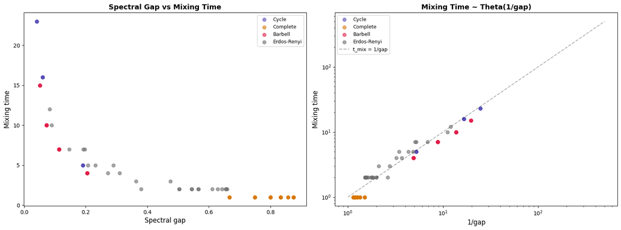

```python
# === Spectral Gap vs Mixing Time ===

fig, axes = plt.subplots(1, 2, figsize=(16, 6))

n_samples = 150
gap_vals, tmix_vals, graph_types_list = [], [], []

for trial in range(n_samples):
    rng_trial = np.random.default_rng(trial)
    if trial < 30:
        n = rng_trial.integers(6, 16)
        p = rng_trial.uniform(0.2, 0.8)
        A = (rng_trial.random((n, n)) < p).astype(float)
        A = np.triu(A, 1); A = A + A.T; np.fill_diagonal(A, 0)
        gtype = 'Erdos-Renyi'
    elif trial < 60:
        n = rng_trial.integers(5, 13); A = path_graph(n); gtype = 'Path'
    elif trial < 90:
        n = rng_trial.integers(5, 13); A = cycle_graph(n); gtype = 'Cycle'
    elif trial < 120:
        k = rng_trial.integers(3, 7); A = barbell_graph(k); gtype = 'Barbell'
    else:
        n = rng_trial.integers(4, 10); A = complete_graph(n); gtype = 'Complete'

    G = nx.from_numpy_array(A)
    if not nx.is_connected(G): continue

    P = transition_matrix(A); pi = stationary_dist(A)
    evals = np.sort(np.real(np.linalg.eigvals(P)))[::-1]
    gap = 1 - max(abs(evals[1]), abs(evals[-1])) if len(evals) > 1 else 1
    if gap < 1e-6: continue

    t_mix = 0
    for t in range(500):
        Pt = np.linalg.matrix_power(P, t)
        worst_tv = max(total_variation(Pt[x], pi) for x in range(len(A)))
        if worst_tv <= 0.25: t_mix = t; break
    else: t_mix = 500

    gap_vals.append(gap); tmix_vals.append(t_mix); graph_types_list.append(gtype)

gap_vals = np.array(gap_vals); tmix_vals = np.array(tmix_vals)

type_colors = {'Path': TEAL, 'Cycle': PURPLE, 'Complete': AMBER, 'Barbell': '#E11D48', 'Erdos-Renyi': SLATE}
ax1 = axes[0]
for gtype, color in type_colors.items():
    mask = np.array([g == gtype for g in graph_types_list])
    if mask.sum() > 0:
        ax1.scatter(gap_vals[mask], tmix_vals[mask], c=color, alpha=0.6, s=40, label=gtype)

ax1.set_xlabel('Spectral gap', fontsize=12)
ax1.set_ylabel('Mixing time', fontsize=12)
ax1.set_title('Spectral Gap vs Mixing Time', fontsize=13, fontweight='bold')
ax1.legend(fontsize=9)

ax2 = axes[1]
for gtype, color in type_colors.items():
    mask = np.array([g == gtype for g in graph_types_list])
    valid = mask & (gap_vals > 0)
    if valid.sum() > 0:
        ax2.scatter(1.0/gap_vals[valid], tmix_vals[valid], c=color, alpha=0.6, s=40, label=gtype)

ax2.plot([1, 500], [1, 500], '--', color='black', alpha=0.3, label='t_mix = 1/gap')
ax2.set_xlabel('1/gap', fontsize=12); ax2.set_ylabel('Mixing time', fontsize=12)
ax2.set_title('Mixing Time ~ Theta(1/gap)', fontsize=13, fontweight='bold')
ax2.set_xscale('log'); ax2.set_yscale('log'); ax2.legend(fontsize=9)

plt.tight_layout()
plt.savefig('spectral-gap-mixing-scatter.png', dpi=150, bbox_inches='tight', facecolor='white')
plt.show()
```

## 5. Lazy Random Walks

**Definition 7 (Lazy Random Walk).** $P_{\text{lazy}} = \frac{1}{2}(I + P)$. At each step, stay with probability $1/2$, move with probability $1/2$.

**Proposition 1 (Lazy Walk Spectrum).** If $\mu_i$ are eigenvalues of $P$, then $\mu_i^{(\text{lazy})} = (1 + \mu_i)/2$.

*Proof.* $P_{\text{lazy}} \mathbf{v} = \frac{1}{2}(I + P)\mathbf{v} = \frac{1 + \mu_i}{2}\mathbf{v}$. $\square$

Since $\mu_i \in [-1, 1]$, we have $\mu_i^{(\text{lazy})} \in [0, 1]$ — no negative eigenvalues, no oscillation. The walk converges even on bipartite graphs, at the cost of halving the spectral gap: $\gamma_{\text{lazy}} = \gamma / 2$.

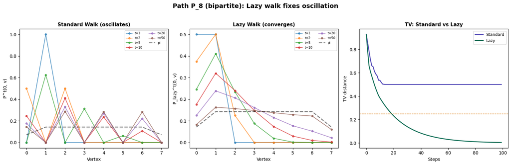

```python
# === Lazy vs Standard Walk on Bipartite Path Graph ===

fig, axes = plt.subplots(1, 3, figsize=(16, 5))
A = path_graph(8)
P = transition_matrix(A)
P_lazy = 0.5 * (np.eye(len(A)) + P)
pi = stationary_dist(A)
n = len(A)

# Standard walk oscillation
ax = axes[0]
for t in [1, 2, 5, 10, 20, 50]:
    Pt = np.linalg.matrix_power(P, t)
    ax.plot(range(n), Pt[0], 'o-', markersize=4, label=f't={t}', alpha=0.7)
ax.plot(range(n), pi, 'k--', linewidth=2, label='pi', alpha=0.5)
ax.set_xlabel('Vertex'); ax.set_ylabel('P^t(0, v)')
ax.set_title('Standard Walk (oscillates)', fontsize=11, fontweight='bold')
ax.legend(fontsize=7, ncol=2)

# Lazy walk convergence
ax = axes[1]
for t in [1, 2, 5, 10, 20, 50]:
    Pt = np.linalg.matrix_power(P_lazy, t)
    ax.plot(range(n), Pt[0], 'o-', markersize=4, label=f't={t}', alpha=0.7)
ax.plot(range(n), pi, 'k--', linewidth=2, label='pi', alpha=0.5)
ax.set_xlabel('Vertex'); ax.set_ylabel('P_lazy^t(0, v)')
ax.set_title('Lazy Walk (converges)', fontsize=11, fontweight='bold')
ax.legend(fontsize=7, ncol=2)

# TV comparison
ax = axes[2]
max_t = 100
tv_std = [max(total_variation(np.linalg.matrix_power(P, t)[x], pi) for x in range(n)) for t in range(max_t)]
tv_laz = [max(total_variation(np.linalg.matrix_power(P_lazy, t)[x], pi) for x in range(n)) for t in range(max_t)]
ax.plot(range(max_t), tv_std, color=PURPLE, linewidth=2, label='Standard')
ax.plot(range(max_t), tv_laz, color=TEAL, linewidth=2, label='Lazy')
ax.axhline(y=0.25, color=AMBER, linestyle='--', linewidth=1)
ax.set_xlabel('Steps'); ax.set_ylabel('TV distance')
ax.set_title('TV: Standard vs Lazy', fontsize=11, fontweight='bold')
ax.legend(fontsize=9)

plt.suptitle('Path P_8 (bipartite): Lazy walk fixes oscillation', fontsize=14, fontweight='bold', y=1.02)
plt.tight_layout()
plt.savefig('lazy-vs-standard-bipartite.png', dpi=150, bbox_inches='tight', facecolor='white')
plt.show()
```

## 6. Hitting Times & Commute Times

**Definition 8 (Hitting Time).** $h(i, j) = \mathbb{E}_i[\min\{t \geq 0 : X_t = j\}]$

Satisfies: $h(i, j) = 1 + \sum_{k \neq j} P_{ik} \, h(k, j)$ for $i \neq j$.

**Proposition 2.** For each target $j$, solve $(I - P_{\bar{j}}) \mathbf{h}_j = \mathbf{1}$.

**Definition 9 (Commute Time).** $\kappa(i, j) = h(i, j) + h(j, i)$ — symmetric.

**Definition 10 (Effective Resistance).** $R_{\text{eff}}(i, j) = (\mathbf{e}_i - \mathbf{e}_j)^T L^\dagger (\mathbf{e}_i - \mathbf{e}_j)$

**Theorem 7 (Commute Time-Effective Resistance Identity).** $\kappa(i, j) = 2m \cdot R_{\text{eff}}(i, j)$

*Proof sketch.* Express $h(i,j)$ via the fundamental matrix $Z = (I - P + \boldsymbol{1}\boldsymbol{\pi}^T)^{-1}$ and relate $Z$ to $L^\dagger$. See Doyle & Snell (1984). $\square$

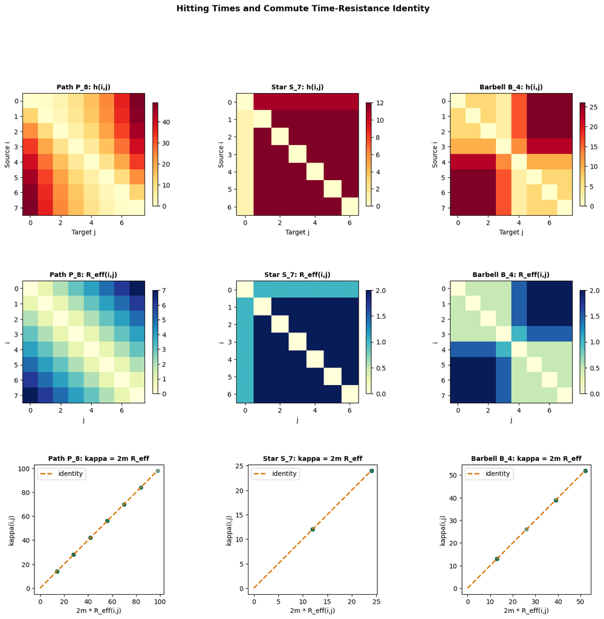

```
Numerical verification:
  Path P_8: max|kappa - 2m*R_eff| = 9.95e-14
  Star S_7: max|kappa - 2m*R_eff| = 2.13e-14
  Barbell B_4: max|kappa - 2m*R_eff| = 5.68e-14
```

```python
# === Hitting Times, Commute Times, and Effective Resistance ===

fig = plt.figure(figsize=(16, 14))
gs = gridspec.GridSpec(3, 3, hspace=0.45, wspace=0.4)

test_graphs_ht = {
    'Path P_8': path_graph(8),
    'Star S_7': star_graph(7),
    'Barbell B_4': barbell_graph(4),
}

for g_idx, (name, A) in enumerate(test_graphs_ht.items()):
    n = len(A)
    m = A.sum() / 2
    H = all_pairs_hitting_times(A)
    K = H + H.T
    R = effective_resistance_matrix(A)

    # Hitting time heatmap
    ax1 = fig.add_subplot(gs[0, g_idx])
    im1 = ax1.imshow(H, cmap='YlOrRd', aspect='equal')
    ax1.set_title(f'{name}: h(i,j)', fontsize=10, fontweight='bold')
    ax1.set_xlabel('Target j'); ax1.set_ylabel('Source i')
    fig.colorbar(im1, ax=ax1, shrink=0.8)

    # Effective resistance heatmap
    ax2 = fig.add_subplot(gs[1, g_idx])
    im2 = ax2.imshow(R, cmap='YlGnBu', aspect='equal')
    ax2.set_title(f'{name}: R_eff(i,j)', fontsize=10, fontweight='bold')
    ax2.set_xlabel('j'); ax2.set_ylabel('i')
    fig.colorbar(im2, ax=ax2, shrink=0.8)

    # Verify identity
    ax3 = fig.add_subplot(gs[2, g_idx])
    commute_flat = K[np.triu_indices(n, k=1)]
    resist_flat = R[np.triu_indices(n, k=1)]
    ax3.scatter(2 * m * resist_flat, commute_flat, c=TEAL, alpha=0.6, s=30)
    max_val = max(commute_flat.max(), (2 * m * resist_flat).max())
    ax3.plot([0, max_val], [0, max_val], '--', color=AMBER, linewidth=2, label='identity')
    ax3.set_xlabel('2m * R_eff(i,j)'); ax3.set_ylabel('kappa(i,j)')
    ax3.set_title(f'{name}: kappa = 2m R_eff', fontsize=10, fontweight='bold')
    ax3.legend(); ax3.set_aspect('equal')

plt.suptitle('Hitting Times and Commute Time-Resistance Identity', fontsize=13, fontweight='bold', y=1.01)
plt.savefig('hitting-time-heatmaps.png', dpi=150, bbox_inches='tight', facecolor='white')
plt.show()

print("Numerical verification:")
for name, A in test_graphs_ht.items():
    m = A.sum() / 2
    H = all_pairs_hitting_times(A)
    K = H + H.T
    R = effective_resistance_matrix(A)
    err = np.max(np.abs(K - 2 * m * R))
    print(f"  {name}: max|kappa - 2m*R_eff| = {err:.2e}")
```

## 7. Effective Resistance & Electrical Networks

Replace each edge with a unit resistor. The Laplacian is the **conductance matrix**: $L\mathbf{v} = \mathbf{i}_{\text{ext}}$.

**Properties of effective resistance** (it is a metric on $V$):

1. $R_{\text{eff}}(i,j) \geq 0$ with equality iff $i = j$.
2. Symmetric: $R_{\text{eff}}(i,j) = R_{\text{eff}}(j,i)$.
3. Triangle inequality: $R_{\text{eff}}(i,k) \leq R_{\text{eff}}(i,j) + R_{\text{eff}}(j,k)$.

Adding edges decreases resistance; removing edges increases it.

**Random Target Lemma:** $\sum_{i < j} R_{\text{eff}}(i,j) = n \cdot \mathrm{tr}(L^\dagger) = n \sum_{k=2}^n 1/\lambda_k$.

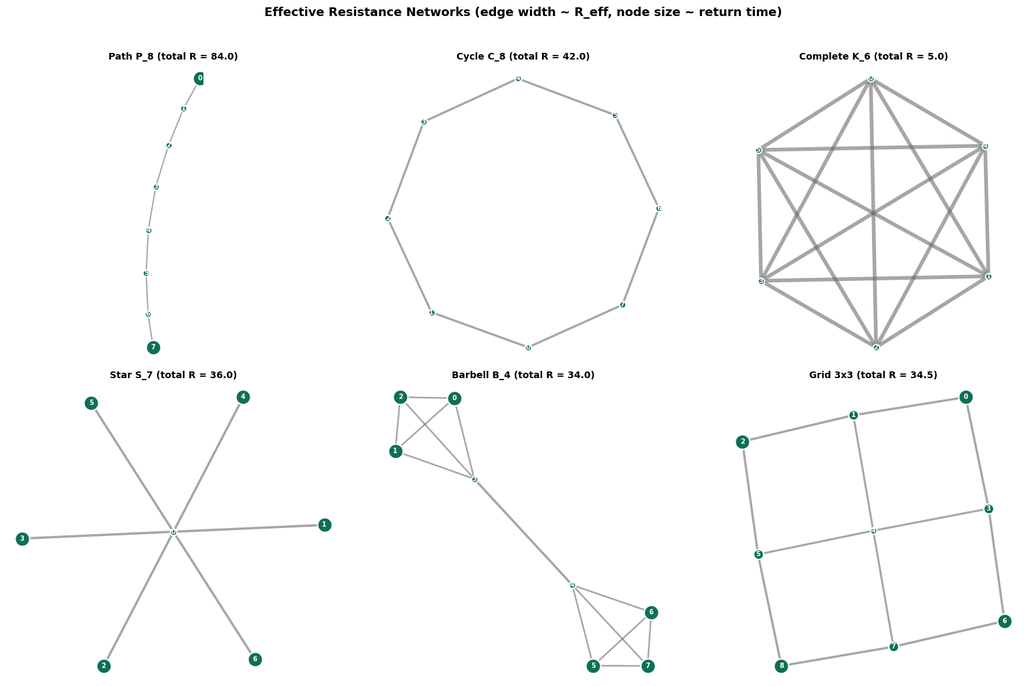

```
Total effective resistance (connected to Laplacian spectrum):
  Path P_8: sum R_eff = 84.000, n*tr(Ldagger) = 84.000
  Cycle C_8: sum R_eff = 42.000, n*tr(Ldagger) = 42.000
  Complete K_6: sum R_eff = 5.000, n*tr(Ldagger) = 5.000
  Star S_7: sum R_eff = 36.000, n*tr(Ldagger) = 36.000
  Barbell B_4: sum R_eff = 34.000, n*tr(Ldagger) = 34.000
  Grid 3x3: sum R_eff = 34.500, n*tr(Ldagger) = 34.500
```

```python
# === Effective Resistance Network Visualization ===

fig, axes = plt.subplots(2, 3, figsize=(16, 10))

test_graphs_res = {
    'Path P_8': path_graph(8),
    'Cycle C_8': cycle_graph(8),
    'Complete K_6': complete_graph(6),
    'Star S_7': star_graph(7),
    'Barbell B_4': barbell_graph(4),
    'Grid 3x3': grid_graph(3),
}

for idx, (name, A) in enumerate(test_graphs_res.items()):
    row, col = divmod(idx, 3)
    ax = axes[row, col]
    n = len(A)
    R = effective_resistance_matrix(A)
    pi = stationary_dist(A)

    G_nx = nx.from_numpy_array(A)
    pos = nx.spring_layout(G_nx, seed=42)

    # Edges with width proportional to R_eff
    for u, v in G_nx.edges():
        r_ij = R[u, v]
        p1, p2 = pos[u], pos[v]
        ax.plot([p1[0], p2[0]], [p1[1], p2[1]],
                color=SLATE, linewidth=1 + 3 * r_ij / max(R.max(), 0.01), alpha=0.6)

    # Nodes with size proportional to return time
    return_times = 1.0 / np.maximum(pi, 0.01)
    sizes = 50 + 200 * (return_times - return_times.min()) / max(return_times.max() - return_times.min(), 1)
    for i in G_nx.nodes():
        p = pos[i]
        ax.scatter(p[0], p[1], s=sizes[i], c=TEAL, edgecolors='white', linewidths=1.5, zorder=5)
        ax.text(p[0], p[1], str(i), fontsize=7, ha='center', va='center', color='white', fontweight='bold', zorder=6)

    total_R = R[np.triu_indices(n, k=1)].sum()
    ax.set_title(f'{name} (total R = {total_R:.1f})', fontsize=10, fontweight='bold')
    ax.set_aspect('equal'); ax.axis('off')

plt.suptitle('Effective Resistance Networks (edge width ~ R_eff, node size ~ return time)',
             fontsize=13, fontweight='bold', y=1.02)
plt.tight_layout()
plt.savefig('effective-resistance-network.png', dpi=150, bbox_inches='tight', facecolor='white')
plt.show()

print("Total effective resistance (connected to Laplacian spectrum):")
for name, A in test_graphs_res.items():
    n = len(A)
    R = effective_resistance_matrix(A)
    total_R = R[np.triu_indices(n, k=1)].sum()
    L = laplacian_matrix(A)
    evals = np.sort(np.linalg.eigvalsh(L))
    trace_Ldagger = np.sum(1.0 / evals[1:])
    print(f"  {name}: sum R_eff = {total_R:.3f}, n*tr(Ldagger) = {n * trace_Ldagger:.3f}")
```

## 8. Applications: PageRank, DeepWalk, Label Propagation

### 8.1 PageRank

$P_{\text{PR}} = \alpha P + (1 - \alpha) \frac{1}{n}\mathbf{1}\mathbf{1}^T$ with $\alpha = 0.85$.

The teleportation term guarantees ergodicity. The spectral gap is at least $1 - \alpha$, giving $O(\frac{1}{1-\alpha} \log n)$ mixing.

### 8.2 DeepWalk and node2vec

Random walks as "sentences," vertices as "words," skip-gram for embeddings. Implicitly factorizes a matrix related to $\log(\max(P^k, 1))$.

### 8.3 Label Propagation

$\mathbf{y}^{(t+1)} = \alpha P \mathbf{y}^{(t)} + (1 - \alpha) \mathbf{y}^{(0)}$. At convergence, labels are discounted random walk averages.

**Remark (Over-Smoothing in GNNs).** Stacking $t$ GCN layers applies $P^t$ to features. By convergence theorem, $P^t \to \boldsymbol{1}\boldsymbol{\pi}^T$ — all features collapse. **Message Passing & GNNs** *(coming soon)* addresses solutions.

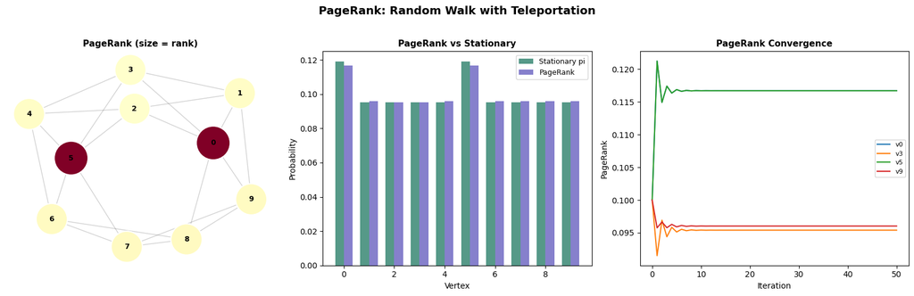

```python
# === PageRank on a Small Web Graph ===

fig, axes = plt.subplots(1, 3, figsize=(16, 5))

n_pages = 10
A_web = np.zeros((n_pages, n_pages))
links = [(0,1),(0,2),(1,2),(1,3),(2,0),(2,4),(3,4),(3,5),(4,5),(4,6),
         (5,6),(5,7),(6,7),(6,8),(7,8),(7,9),(8,9),(8,0),(9,0),(9,1),(3,0),(5,2)]
for i, j in links:
    A_web[i, j] = 1
A_web_sym = np.maximum(A_web, A_web.T)
np.fill_diagonal(A_web_sym, 0)

pi_rw = stationary_dist(A_web_sym)
alpha = 0.85
P_web = transition_matrix(A_web_sym)
P_pr = alpha * P_web + (1 - alpha) / n_pages * np.ones((n_pages, n_pages))

r = np.ones(n_pages) / n_pages
for _ in range(100):
    r = r @ P_pr
r = r / r.sum()

# Graph with PageRank coloring
ax1 = axes[0]
G_web = nx.from_numpy_array(A_web_sym)
pos = nx.spring_layout(G_web, seed=42)
nx.draw_networkx_edges(G_web, pos, ax=ax1, alpha=0.3, edge_color=SLATE)
nx.draw_networkx_nodes(G_web, pos, ax=ax1, node_color=r, cmap=plt.cm.YlOrRd,
                       node_size=300 + 1500*r/r.max(), edgecolors='white', linewidths=1.5)
nx.draw_networkx_labels(G_web, pos, ax=ax1, font_size=9, font_weight='bold')
ax1.set_title('PageRank (size = rank)', fontsize=11, fontweight='bold'); ax1.axis('off')

# PageRank vs stationary
ax2 = axes[1]
x_pos = np.arange(n_pages); width = 0.35
ax2.bar(x_pos - width/2, pi_rw, width, color=TEAL, alpha=0.7, label='Stationary pi')
ax2.bar(x_pos + width/2, r, width, color=PURPLE, alpha=0.7, label='PageRank')
ax2.set_xlabel('Vertex'); ax2.set_ylabel('Probability')
ax2.set_title('PageRank vs Stationary', fontsize=11, fontweight='bold'); ax2.legend(fontsize=9)

# Convergence
ax3 = axes[2]
r_hist = [np.ones(n_pages)/n_pages]
r_t = np.ones(n_pages)/n_pages
for t in range(50):
    r_t = r_t @ P_pr; r_t = r_t / r_t.sum()
    r_hist.append(r_t.copy())
for i in [0, 3, 5, 9]:
    ax3.plot([r_hist[t][i] for t in range(len(r_hist))], label=f'v{i}', linewidth=1.5)
ax3.set_xlabel('Iteration'); ax3.set_ylabel('PageRank')
ax3.set_title('PageRank Convergence', fontsize=11, fontweight='bold'); ax3.legend(fontsize=8)

plt.suptitle('PageRank: Random Walk with Teleportation', fontsize=14, fontweight='bold', y=1.02)
plt.tight_layout()
plt.savefig('pagerank-web-graph.png', dpi=150, bbox_inches='tight', facecolor='white')
plt.show()
```

## 9. Computational Notes

```python
# === Computational Notes ===

print("=== 1. Transition Matrix ===")
A_ex = cycle_graph(6)
D_ex = np.diag(A_ex.sum(axis=1))
P_ex = np.linalg.inv(D_ex) @ A_ex
print(f"P = D^-1 A for C_6:"); print(np.round(P_ex, 3))

print("\n=== 2. Stationary Distribution ===")
pi_ex = stationary_dist(A_ex)
print(f"pi for C_6: {np.round(pi_ex, 4)}")
print(f"Verify pi^T P = pi^T: max error = {np.max(np.abs(pi_ex @ P_ex - pi_ex)):.2e}")

print("\n=== 3. Spectral Gap ===")
evals_norm = np.sort(np.linalg.eigvalsh(normalized_laplacian(A_ex)))
evals_P_ex = np.sort(np.real(np.linalg.eigvals(P_ex)))[::-1]
print(f"lambda_2(L_norm) = {evals_norm[1]:.4f}")
print(f"gap = 1 - mu_2 = {1 - evals_P_ex[1]:.4f}")
print(f"Match: {abs(1 - evals_P_ex[1] - evals_norm[1]) < 1e-10}")

print("\n=== 4. Hitting Times ===")
H_ex = all_pairs_hitting_times(A_ex)
print(f"h(0,3) on C_6 = {H_ex[0,3]:.2f}")

print("\n=== 5. Effective Resistance ===")
R_ex = effective_resistance_matrix(A_ex)
m_ex = A_ex.sum() / 2
print(f"Verify kappa(0,3) = 2m*R_eff(0,3): {H_ex[0,3] + H_ex[3,0]:.4f} vs {2*m_ex*R_ex[0,3]:.4f}")

print("\n=== 6. NetworkX ===")
G_nx = nx.cycle_graph(6)
print(f"Algebraic connectivity: {nx.algebraic_connectivity(G_nx):.4f}")

print("\n=== 7. Sparse Laplacian ===")
from scipy import sparse
L_sparse = sparse.csgraph.laplacian(sparse.csr_matrix(A_ex))
print(f"Sparse Laplacian shape: {L_sparse.shape}")
```

```
=== 1. Transition Matrix ===
P = D^-1 A for C_6:
[[0.  0.5 0.  0.  0.  0.5]
 [0.5 0.  0.5 0.  0.  0. ]
 [0.  0.5 0.  0.5 0.  0. ]
 [0.  0.  0.5 0.  0.5 0. ]
 [0.  0.  0.  0.5 0.  0.5]
 [0.5 0.  0.  0.  0.5 0. ]]

=== 2. Stationary Distribution ===
pi for C_6: [0.1667 0.1667 0.1667 0.1667 0.1667 0.1667]
Verify pi^T P = pi^T: max error = 0.00e+00

=== 3. Spectral Gap ===
lambda_2(L_norm) = 0.5000
gap = 1 - mu_2 = 0.5000
Match: True

=== 4. Hitting Times ===
h(0,3) on C_6 = 9.00

=== 5. Effective Resistance ===
Verify kappa(0,3) = 2m*R_eff(0,3): 18.0000 vs 18.0000

=== 6. NetworkX ===
Algebraic connectivity: 1.0000

=== 7. Sparse Laplacian ===
Sparse Laplacian shape: (6, 6)
```

## Connections & Further Reading

### Cross-Track and Within-Track Connections

| Topic | Track | Connection |
| --- | --- | --- |
| Graph Laplacians & Spectrum | Graph Theory | $P = D^{-1}A$ complements $L_{\text{rw}} = I - P$. Spectral gap $\gamma = \lambda_2(\mathcal{L})$. |
| The Spectral Theorem | Linear Algebra | $P$ is similar to symmetric $D^{-1/2}AD^{-1/2}$. Spectral decomposition of $P^t$ underlies all bounds. |
| Shannon Entropy | Information Theory | $D_{\mathrm{KL}}(P^t(x,\cdot) \\| \boldsymbol{\pi})$ decreases monotonically. $H(\boldsymbol{\pi}) = \log n$ iff regular. |
| Measure-Theoretic Probability | Probability | Convergence in TV = convergence in $L^1$. Ergodic theorem: time averages converge a.s. |
| Concentration Inequalities | Probability | Chernoff bounds for Markov chain sums use spectral gap. |
| PCA & Low-Rank Approximation | Linear Algebra | DeepWalk/node2vec = implicit factorization of walk probabilities. |
| **Expander Graphs** *(coming soon)* | Graph Theory | Expanders have $\gamma \geq c > 0$ and mix in $O(\log n)$. |
| **Message Passing & GNNs** *(coming soon)* | Graph Theory | Over-smoothing = walk convergence. GNN depth should match $1/\gamma$. |

### Notation Summary

| Symbol | Name | Definition |
| --- | --- | --- |
| $P$ | Transition matrix | $D^{-1}A$ |
| $\boldsymbol{\pi}$ | Stationary distribution | $\pi_i = d_i/(2m)$ |
| $\gamma$ | Spectral gap | $1 - \lambda_\star$ |
| $t_{\mathrm{mix}}$ | Mixing time | Worst-case TV convergence to $\varepsilon$ |
| $P_{\text{lazy}}$ | Lazy walk | $(I + P)/2$ |
| $h(i,j)$ | Hitting time | Expected first passage time |
| $\kappa(i,j)$ | Commute time | $h(i,j) + h(j,i) = 2m R_{\text{eff}}(i,j)$ |
| $R_{\text{eff}}$ | Effective resistance | $(e_i - e_j)^T L^\dagger (e_i - e_j)$ |